# figs_1_2_s7_s8_s11_correlation_violin_plots

Sanmi Adenaiye

Don Milton

4/15/2021; 7/17/2021

correlation plots, violin plots

# use replicate per row data from paired and nonpaired sets, screened for seronegative

```r
rpr_paired <- read.csv("../working_files/paired_pcr_sx_rpr.csv")
pcr_dat <- rpr_paired %>% filter(pos_enrollment=="Negative")

rpr_nonpaired <- read.csv("../working_files/nonpaired_pcr_sx_rpr.csv")
pcr_dat_nonpaired <- rpr_nonpaired %>% filter(pos_enrollment=="Negative")

# number of subjects and samples per sample type
pcr_dat %>% group_by(sample_type) %>% summarise(subjects=length(unique(study_id)),samples=n())
```

```
## # A tibble: 10 x 3
##    sample_type              subjects samples
##    <fct>                       <int>   <int>
##  1 G-II Coarse Aerosol            46     138
##  2 G-II Coarse Aerosol mask       46     138
##  3 G-II Cone Swab                 41     124
##  4 G-II Cone Swab mask            41     124
##  5 G-II Fine Aerosol              46     138
##  6 G-II Fine Aerosol mask         46     138
##  7 IcePac                         11      32
##  8 Midturbinate Swab              46     138
##  9 Phone Swab                     46     138
## 10 Saliva                         46     137
```

rearrange data for ggplot:

replace -1 with NA for the non-detects find mean ct per sample - this will exclude non-detects when estimating the mean log10(x+1),x=rna copies - this will keep non-detects as zero in the plots replace NA with 41 for the non-detects

```r
#mean n_gene Ct per sample
pcr_dat$ngene_CT <- pcr_dat$ct_ngene_qpcr
pcr_dat$ngene_CT[which(pcr_dat$ngene_CT==-1)] <- NA #replace CT of non detects with NA so it won't contribute to the mean estimate

pcr_dat <- pcr_dat %>% group_by(sample_id) %>% mutate(av_ngene_CT=mean(ngene_CT,na.rm = T)) #average CT values so non-detects are excluded from the mean
pcr_dat$id_date <- paste(pcr_dat$study_id,pcr_dat$sample_date,sep="-") # helper
pcr_dat$av_ngene <- (pcr_dat$av_quant + 1) %>% log10() # add 1 to the copy numbers to avoid undefined log 0
pcr_dat <- pcr_dat %>% distinct(sample_id,.keep_all = T) %>% #keep one replicate per sample
  mutate(av_ngene_CT=if_else(is.nan(av_ngene_CT),41,av_ngene_CT)) %>%
  ungroup() #replace Ct value of non-detects with 41

pcr_dat %>% group_by(sample_type) %>% summarise(subjects=length(unique(study_id)),samples=n())
```

```
## # A tibble: 10 x 3
##    sample_type              subjects samples
##    <fct>                       <int>   <int>
##  1 G-II Coarse Aerosol            46      69
##  2 G-II Coarse Aerosol mask       46      69
##  3 G-II Cone Swab                 41      62
##  4 G-II Cone Swab mask            41      62
##  5 G-II Fine Aerosol              46      69
##  6 G-II Fine Aerosol mask         46      69
##  7 IcePac                         11      16
##  8 Midturbinate Swab              46      69
##  9 Phone Swab                     46      69
## 10 Saliva                         46      69
```

Data frame for the correlation plots

```r
# remove phone swabs from the correlation plots
plot_cor <- pcr_dat %>% filter(sample_type!="Phone Swab")
plot_cor$S.gene.dropout <- factor(plot_cor$S.gene.dropout, levels=c(T,F), labels=c("True","False"))
plot_cor <- plot_cor %>% select(study_id,sample_date,id_date,av_ngene_CT,S.gene.dropout,av_ngene,sample_type,ct_ngene_qpcr,ct_sgene_qpcr,age_entry,days_past_onset,bmi)

plot_cor %>% group_by(sample_type) %>% summarise(subjects=length(unique(study_id)),samples=n())
```

```
## # A tibble: 9 x 3
##   sample_type              subjects samples
##   <fct>                       <int>   <int>
## 1 G-II Coarse Aerosol            46      69
## 2 G-II Coarse Aerosol mask       46      69
## 3 G-II Cone Swab                 41      62
## 4 G-II Cone Swab mask            41      62
## 5 G-II Fine Aerosol              46      69
## 6 G-II Fine Aerosol mask         46      69
## 7 IcePac                         11      16
## 8 Midturbinate Swab              46      69
## 9 Saliva                         46      69
```

RNA copy number correlation plots

mt/saliva is on the left (i.e. x), while breath samples are on the right (y) i loop through dataframes, keeping all.x=T ensures the base is fully merged and remains consisent while y varies, since there are no consistent numbers of aerosol samples per id_date when absent, aerosol samples will be NA and will not be plotted

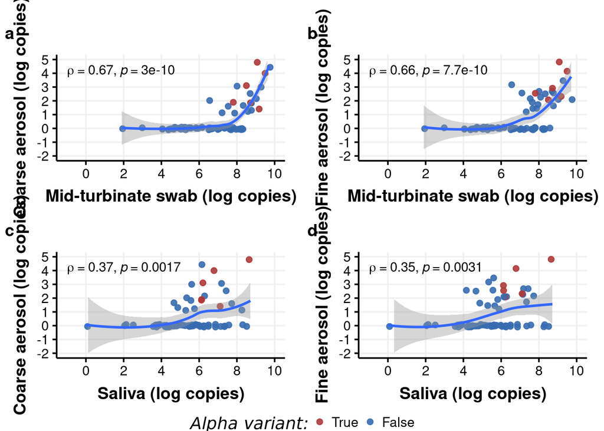

```r
# Exclude masked samples
allsampletypes <- plot_cor$sample_type %>% unique()
plot_cor_samplelist <- allsampletypes %>% lapply(function(x) {plot_cor %>% filter(sample_type==x)})
names(plot_cor_samplelist) <- allsampletypes

aer <- list(plot_cor_samplelist[["G-II Coarse Aerosol"]],plot_cor_samplelist[["G-II Fine Aerosol"]])
names(aer) <- c("Coarse aerosol (log copies)","Fine aerosol (log copies)")

# sal vs breath samples
q_sal_plot <- list()
for (i in 1:2) {
  iplot <- plot_cor_samplelist[["Saliva"]] %>% merge(aer[[i]],all.x = T,all.y = F, by = "id_date") %>% rename(`Alpha variant:`=S.gene.dropout.x)
  q_sal_plot[[i]] <- iplot %>%
    ggplot(aes(y=av_ngene.y,x=av_ngene.x)) +
    geom_point(aes(color=`Alpha variant:`),size=2,alpha=0.9,position=position_jitter(h=.1,w=.1,seed=42)) +
    geom_smooth(method = "loess") +
    stat_cor(method = "spearman",cor.coef.name = "rho") +
    ylab(names(aer)[i]) +
    xlab("Saliva (log copies)") +
    scale_y_continuous(breaks=c(-2:5),limits = c(-2, 5)) +
    scale_x_continuous(breaks=c(0,2,4,6,8,10),limits = c(-1, 10)) +
    expand_limits(x=0,y=-2) +
    scale_colour_Publication() +
    theme_Publication()
}
#mt vs breath samples
q_mt_plot <- list()
for (i in 1:2) {
  iplot <- plot_cor_samplelist[["Midturbinate Swab"]] %>% merge(aer[[i]],all.x = T,all.y = F, by = "id_date") %>% rename(`Alpha variant:`=S.gene.dropout.x)
  q_mt_plot[[i]] <- iplot %>%
    ggplot(aes(y=av_ngene.y,x=av_ngene.x)) +
    geom_point(aes(color=`Alpha variant:`),size=2,alpha=0.9,position=position_jitter(h=.1,w=.1,seed=42)) +
    geom_smooth(method = "loess") +
    stat_cor(method = "spearman",cor.coef.name = "rho") +
    ylab(names(aer)[i]) +
    xlab("Mid-turbinate swab (log copies)") +
    scale_y_continuous(breaks=c(-2:5),limits = c(-2, 5)) +
    scale_x_continuous(breaks=c(0,2,4,6,8,10),limits = c(-1, 10)) +
    expand_limits(x=0,y=-2) +
    scale_colour_Publication() +
    theme_Publication()
}
# Combine the plots into the one figure

Figure2 <- ggarrange(q_mt_plot[[1]],q_mt_plot[[2]],q_sal_plot[[1]],q_sal_plot[[2]],
                     common.legend = T,
                     legend = "bottom",
                     labels = "auto") %>%
  annotate_figure(top = text_grob("",color = "black", face = "bold", size = 14))
Figure2
```

```r
ggsave(Figure2,filename="../figure_output/repo_fig_2_mtsalbreath_logcopies_corr.png",device="png",width=11,height=7.77,units="in")
```

CT correlation plots

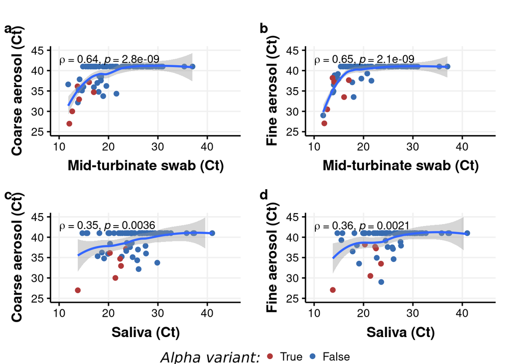

```r
aer2 <- list(plot_cor_samplelist[["G-II Fine Aerosol"]],plot_cor_samplelist[["G-II Coarse Aerosol"]])
names(aer2) <- c("Coarse aerosol","Fine aerosol")

#sal vs aerosol
ct_sal_plot <- list()
for (i in 1:2) {
  iplot <- plot_cor_samplelist[["Saliva"]] %>% merge(aer2[[i]],all.x = F,all.y = F, by = "id_date") %>% rename(`Alpha variant:`=S.gene.dropout.x)
  ct_sal_plot[[i]] <- iplot %>%
    ggplot(aes(y=av_ngene_CT.y,x=av_ngene_CT.x)) +
    geom_point(aes(color=`Alpha variant:`),size=2) +
    geom_smooth(method = "loess", formula = y ~ x) +
    stat_cor(method = "spearman",cor.coef.name = "rho") +
    ylab(paste0(names(aer2)[i]," (Ct)")) +
    xlab("Saliva (Ct)") +
    scale_y_continuous(breaks=c(10,15,20,25,30,35,40,45),limits = c(25,45)) +
    scale_x_continuous(breaks=c(10,20,30,40),limits = c(10, 45)) +
    scale_colour_Publication() +
    theme_Publication()
}

#mt vs aerosol
ct_mt_plot <- list()
for (i in 1:2) {
  iplot <- plot_cor_samplelist[["Midturbinate Swab"]] %>% merge(aer2[[i]],all.x = F,all.y = F, by = "id_date") %>% rename(`Alpha variant:`=S.gene.dropout.x)
  ct_mt_plot[[i]] <- iplot %>%
    ggplot(aes(y=av_ngene_CT.y,x=av_ngene_CT.x)) +
    geom_point(aes(color=`Alpha variant:`),size=2) +
    geom_smooth(method = "loess", formula = y ~ x) +
    stat_cor(method = "spearman",cor.coef.name = "rho") +
    ylab(paste0(names(aer2)[i]," (Ct)")) +
    xlab("Mid-turbinate swab (Ct)") +
    scale_y_continuous(breaks=c(10,15,20,25,30,35,40,45),limits = c(25,45)) +
    scale_x_continuous(breaks=c(10,20,30,40),limits = c(10, 45)) +
    scale_colour_Publication() +
    theme_Publication()
}

figS7 <- ggarrange(ct_mt_plot[[1]],ct_mt_plot[[2]],ct_sal_plot[[1]],ct_sal_plot[[2]],
                   common.legend = T,
                   legend = "bottom",
                   labels = "auto") %>%
  annotate_figure(top = text_grob("",color = "black", face = "bold", size = 14))

figS7
```

```r
ggsave(figS7,filename="../figure_output/repo_fig_s7_mtsalbreath_ct_corr.png",device="png",width=11,height=7.77,units="in")
```

MT vs Saliva RNA copies correlation

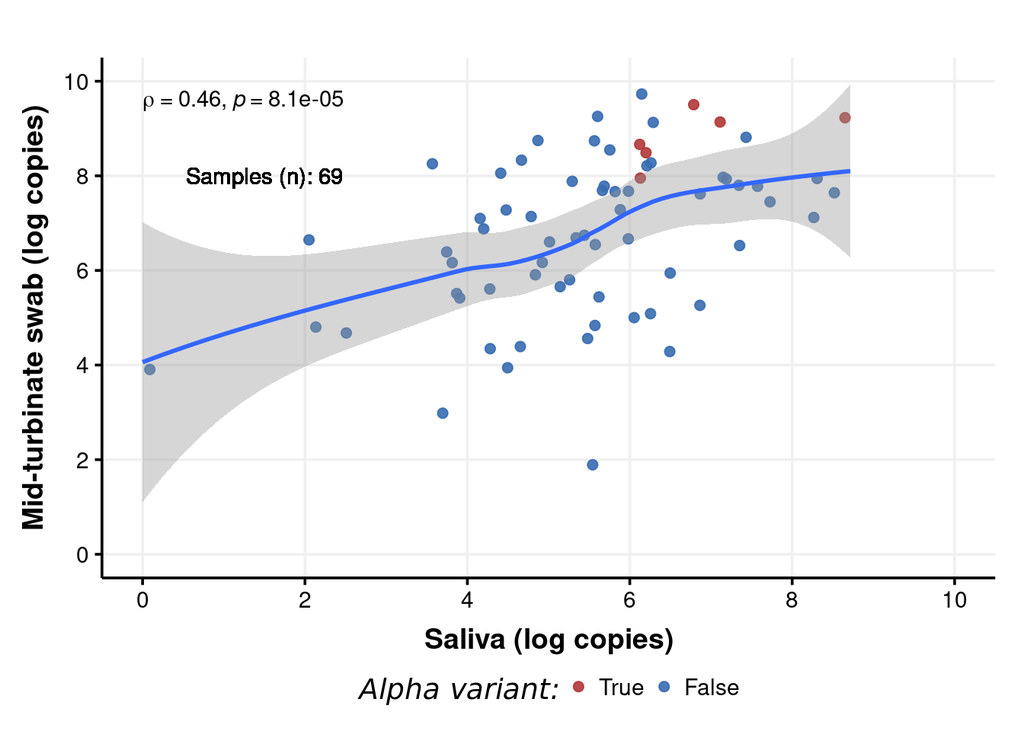

```r
salmt <- merge(plot_cor_samplelist[["Saliva"]],plot_cor_samplelist[["Midturbinate Swab"]],all.x=T,all.y=F,by="id_date") %>% rename(`Alpha variant:`=S.gene.dropout.x)

salmt_plot_q <- ggplot(salmt,aes(y=av_ngene.y,x=av_ngene.x)) +
  geom_point(aes(color=`Alpha variant:`),size=2,alpha=0.9,position=position_jitter(h=.1,w=.1,seed=42)) +
  geom_text(x=1.5,y=8,label=str_wrap(paste("Samples (n): ",sum(!is.na(salmt$av_ngene.y))),15)) +
  geom_smooth(method = "loess", formula = y ~ x) +
  stat_cor(method = "spearman",cor.coef.name = "rho") +
   ylab("Mid-turbinate swab (log copies)") +
  xlab("Saliva (log copies)") +
  scale_y_continuous(breaks=c(0,2,4,6,8,10),limits = c(0, 10)) +
  scale_x_continuous(breaks=c(0,2,4,6,8,10),limits = c(0, 10)) +
  expand_limits(x=0,y=-2) +
  scale_colour_Publication() +
  theme_Publication()
salmt_plot_q
```

#### MT vs Saliva Ct value correlation

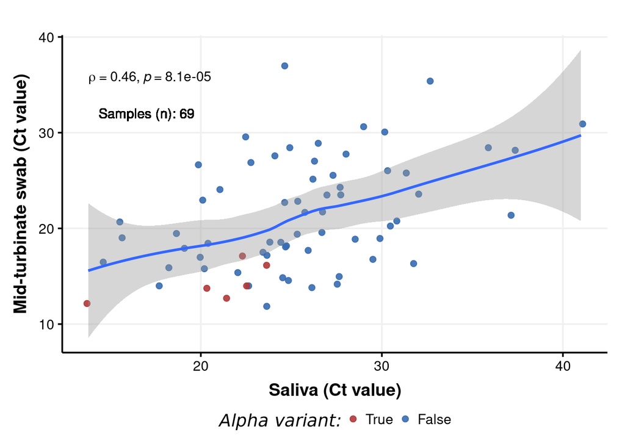

```r
salmt_plot_ct <- ggplot(salmt,aes(y=av_ngene_CT.y,x=av_ngene_CT.x)) +
  geom_point(aes(color=`Alpha variant:`),size=2,alpha=0.9,position=position_jitter(h=.1,w=.1,seed=42)) +
  geom_text(x=17,y=32,label=str_wrap(paste("Samples (n): ",sum(!is.na(salmt$av_ngene.y))),15)) +
  geom_smooth(method = "loess", formula = y ~ x) +
  stat_cor(method="spearman",cor.coef.name = "rho") +
  ylab("Mid-turbinate swab (Ct value)") +
  xlab("Saliva (Ct value)") +
  scale_colour_Publication() +
  theme_Publication()
salmt_plot_ct
```

Combine mt_sal Ct and RNA plots

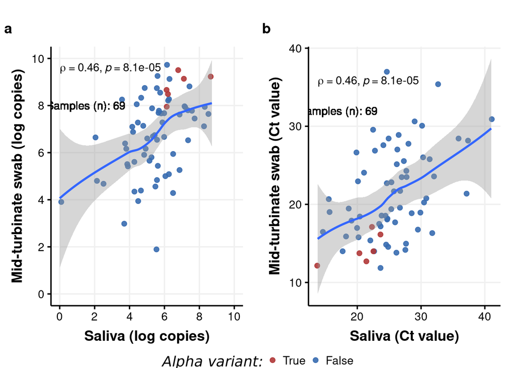

```r
FigureS8 <- ggarrange(salmt_plot_q,salmt_plot_ct,common.legend = T,legend = "bottom",labels = "auto") %>%
  annotate_figure(top = text_grob("",color = "black", face = "bold", size = 14))

FigureS8
```

```r
ggsave(FigureS8,filename="../figure_output/repo_fig_s8_mt_saliva_corr.png",device="png",width=11,height=5.75,units="in")
```

# Violin plots

```r
pcr_dat_violin <- pcr_dat
pcr_dat_violin <- pcr_dat_violin %>%  mutate(`S gene dropout2`=(ct_ngene_qpcr>0 & ct_sgene_qpcr<0))

pcr_dat_violin$sample_type <- as.character(pcr_dat_violin$sample_type)
pcr_dat_violin$sample_type[which(pcr_dat_violin$sample_type=="G-II Coarse Aerosol")] <- "Coarse aerosol without mask"
pcr_dat_violin$sample_type[which(pcr_dat_violin$sample_type=="G-II Coarse Aerosol mask")] <- "Coarse aerosol with mask"
pcr_dat_violin$sample_type[which(pcr_dat_violin$sample_type=="G-II Fine Aerosol")] <- "Fine aerosol without mask"
pcr_dat_violin$sample_type[which(pcr_dat_violin$sample_type=="G-II Fine Aerosol mask")] <- "Fine aerosol with mask"

pcr_dat_violin <- pcr_dat_violin %>% filter(sample_type %in% c("Midturbinate Swab","Phone Swab","Saliva","Coarse aerosol without mask","Coarse aerosol with mask","Fine aerosol without mask","Fine aerosol with mask"))

table(pcr_dat_violin$sample_type)
```

```
##
##    Coarse aerosol with mask Coarse aerosol without mask
##                          69                          69
##      Fine aerosol with mask   Fine aerosol without mask
##                          69                          69
##           Midturbinate Swab                  Phone Swab
##                          69                          69
##                      Saliva
##                          69
```

Violin plot for breath samples, MTs, saliva, phone swabs

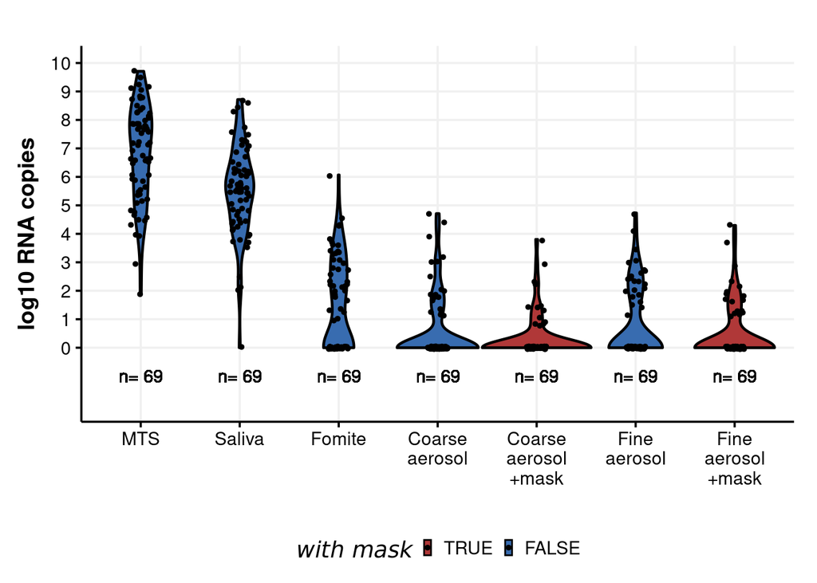

```r
seronegative_breath_violin_dF <- pcr_dat_violin %>% filter(pos_enrollment=="Negative") %>%
  mutate(sample_type=factor(sample_type,
                            levels = c("Midturbinate Swab","Saliva","Phone Swab","Coarse aerosol without mask","Coarse aerosol with mask","Fine aerosol without mask","Fine aerosol with mask"),
                            labels = c("MTS","Saliva","Fomite","Coarse aerosol","Coarse aerosol +mask","Fine aerosol","Fine aerosol +mask")))
seronegative_breath_violin_dF <-seronegative_breath_violin_dF %>% group_by(sample_type) %>% mutate(n=sum(!is.na(av_ngene))) #count number of log RNA copies per sample type to be displayed in the plots

# fill color for nomask breath samples, MT, Saliva, and phone swabs to be red
seronegative_breath_violin_dF$red <- T
seronegative_breath_violin_dF$red[which(seronegative_breath_violin_dF$mask_yn==0)] <- F
seronegative_breath_violin_dF$red[which(seronegative_breath_violin_dF$sample_type %in% c("MTS","Saliva","Fomite"))] <- F

seronegative_breath_violin_plot <- seronegative_breath_violin_dF %>%
  ggplot(aes(x = factor(sample_type), av_ngene,fill=factor(red,levels=c(T,F)),color=mask_yn)) +
  geom_violin(lwd=.8,color="black",width=1.1,position=position_dodge(width=2)) +
  geom_point(lwd=1,color="black",position=position_jitter(h=0.05,w=.1,seed=42)) +
  geom_text(aes(y=-1,label=paste("n=",n)),position = position_dodge(0.5),color="black") +
  labs(y = "log10 RNA copies", x = "") +
  theme(axis.text.x = element_text(angle = 0),legend.position = "none") +
  scale_y_continuous(limits=c(-2,10), breaks = c(0:10)) +
  scale_x_discrete(labels = wrap_format(10.5)) +
  theme_bw() +
  scale_fill_Publication() +
  scale_colour_Publication() +
  theme_Publication() +
  guides(fill=guide_legend(title="with mask")) +
  theme(legend.position = "bottom")
seronegative_breath_violin_plot
```

```r
ggsave(seronegative_breath_violin_plot,filename="../figure_output/repo_fig_1_violin_shedding_paired.png",device="png",width=11,height=5.75,units="in")
```

# Fig s11 (violin plot for display cut-off)

```r
#explore culture status
pcr_dat_violin2 <- pcr_dat_nonpaired
pcr_dat_violin2$ngene_CT <- pcr_dat_violin2$ct_ngene_qpcr
pcr_dat_violin2$ngene_CT[which(pcr_dat_violin2$ngene_CT==-1)] <- NA #replace CT of non detects with NA so it won't contribute to the mean estimate

pcr_dat_violin2 <- pcr_dat_violin2 %>% group_by(sample_id) %>% mutate(av_ngene_CT=mean(ngene_CT,na.rm = T)) #average CT values so non-detects are excluded from the mean
pcr_dat_violin2$id_date <- paste(pcr_dat_violin2$study_id,pcr_dat_violin2$sample_date,sep="-") # helper
pcr_dat_violin2$av_ngene <- (pcr_dat_violin2$av_quant + 1) %>% log10() # add 1 to the copy numbers to avoid undefined log 0
pcr_dat_violin2 <- pcr_dat_violin2 %>% distinct(sample_id,.keep_all = T) %>% #keep one replicate per sample
  mutate(av_ngene_CT=if_else(is.nan(av_ngene_CT),41,av_ngene_CT)) %>%
  ungroup() #replace Ct value of non-detects with 41

pcr_dat_violin2$sample_type <- as.character(pcr_dat_violin2$sample_type)
pcr_dat_violin2$sample_type[which(pcr_dat_violin2$sample_type=="G-II Coarse Aerosol")] <- "Coarse aerosol without mask"
pcr_dat_violin2$sample_type[which(pcr_dat_violin2$sample_type=="G-II Coarse Aerosol mask")] <- "Coarse aerosol with mask"
pcr_dat_violin2$sample_type[which(pcr_dat_violin2$sample_type=="G-II Fine Aerosol")] <- "Fine aerosol without mask"
pcr_dat_violin2$sample_type[which(pcr_dat_violin2$sample_type=="G-II Fine Aerosol mask")] <- "Fine aerosol with mask"

pcr_dat_violin <- pcr_dat_violin %>% filter(sample_type %in% c("Midturbinate Swab","Phone Swab","Saliva","Coarse aerosol without mask","Coarse aerosol with mask","Fine aerosol without mask","Fine aerosol with mask"))

pcr_dat_violin2 <- pcr_dat_violin2 %>% filter(sample_type %in% c("Midturbinate Swab","Phone Swab","Saliva","Coarse aerosol without mask","Coarse aerosol with mask","Fine aerosol without mask","Fine aerosol with mask"))
#
seronegative_breath_violin_dF_nonpaired <- pcr_dat_violin2 %>% filter(pos_enrollment=="Negative") %>%
  mutate(sample_type=factor(sample_type,
                            levels = c("Midturbinate Swab","Saliva","Phone Swab","Coarse aerosol without mask","Coarse aerosol with mask","Fine aerosol without mask","Fine aerosol with mask"),
                            labels = c("MTS","Saliva","Fomite","Coarse aerosol","Coarse aerosol +mask","Fine aerosol","Fine aerosol +mask")))
seronegative_breath_violin_dF_nonpaired <-seronegative_breath_violin_dF_nonpaired %>% group_by(sample_type) %>% mutate(n=sum(!is.na(av_ngene))) #count number of log RNA copies per sample type to be displayed in the plots

table(seronegative_breath_violin_dF_nonpaired$culture_status)
```

```
##
## imputed sample       negative   not cultured       positive
##              1            330            135             72
```

```r
seronegative_breath_violin_dF_cult <- seronegative_breath_violin_dF_nonpaired %>% mutate(sampletype_culturestatus=factor(paste("Culture",culture_status,sample_type)))

table(seronegative_breath_violin_dF_cult$sampletype_culturestatus)
```

```
##
##                      Culture negative MTS
##                                        23
##                  Culture not cultured MTS
##                                         7
##                      Culture positive MTS
##                                        50
##             Culture imputed sample Saliva
##                                         1
##                   Culture negative Saliva
##                                        41
##               Culture not cultured Saliva
##                                        18
##                   Culture positive Saliva
##                                        20
##                   Culture negative Fomite
##                                        73
##               Culture not cultured Fomite
##                                         7
##           Culture negative Coarse aerosol
##                                        38
##       Culture not cultured Coarse aerosol
##                                        40
##     Culture negative Coarse aerosol +mask
##                                        16
## Culture not cultured Coarse aerosol +mask
##                                        55
##             Culture negative Fine aerosol
##                                        75
##         Culture not cultured Fine aerosol
##                                         3
##       Culture negative Fine aerosol +mask
##                                        64
##   Culture not cultured Fine aerosol +mask
##                                         5
##       Culture positive Fine aerosol +mask
##                                         2
```

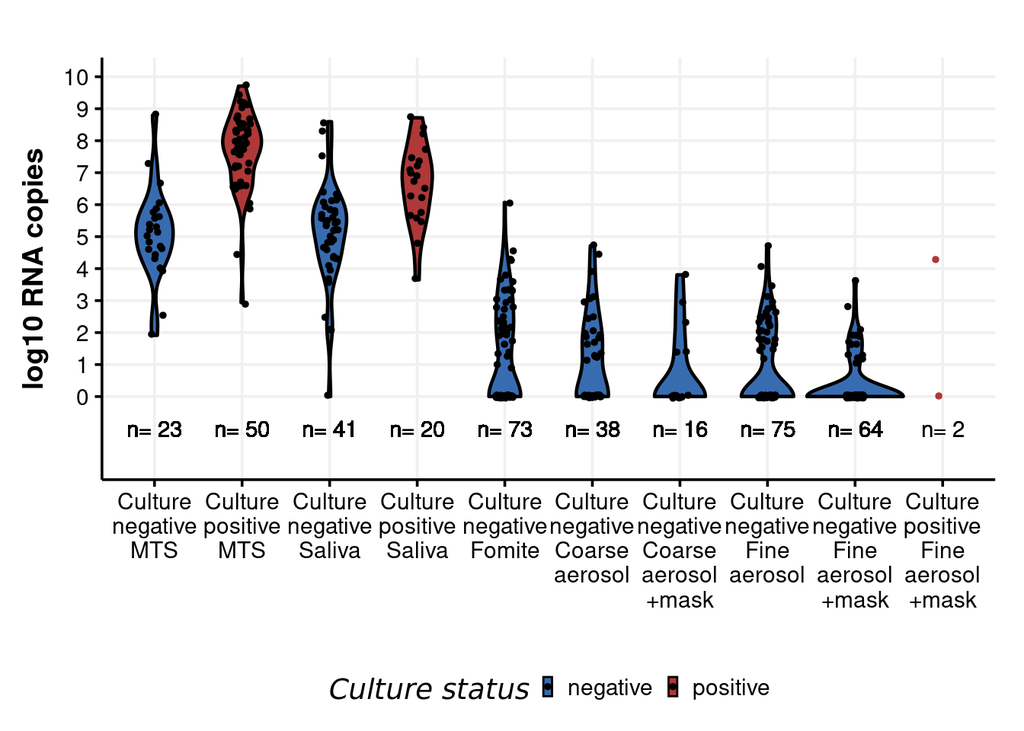

```r
seronegative_breath_violin_dF_cult <- seronegative_breath_violin_dF_cult %>% group_by(sampletype_culturestatus) %>% mutate(n_culture=n())
seronegative_breath_violin_dF_cult1 <- seronegative_breath_violin_dF_cult %>% filter(!(culture_status %in% c("not cultured","imputed sample")) & !grepl("Spray",sample_type)) %>% rename(`Culture status`=culture_status)

# color the fine aerosol masked culture positive points red (#bo3838)
seronegative_breath_violin_dF_cult1$pointcolor <- "black"
seronegative_breath_violin_dF_cult1$pointcolor[seronegative_breath_violin_dF_cult1$sampletype_culturestatus=="Culture positive Fine aerosol +mask"] <- "#b03838"

violin_culture <- seronegative_breath_violin_dF_cult1 %>%
  ggplot(aes(x = (sampletype_culturestatus), av_ngene,fill=`Culture status`,color=mask_yn)) +
  geom_violin(lwd=.8,color="black",width=1.1,position=position_dodge(width=3)) +
  geom_point(lwd=1,color=seronegative_breath_violin_dF_cult1$pointcolor,position=position_jitter(h=0.05,w=.1,seed=42)) +
  geom_text(aes(y=-1,label=paste("n=",n_culture)),position = position_dodge(0.5),color="black") +
  labs(y = "log10 RNA copies", x = "") +
  theme(axis.text.x = element_text(angle = 0),legend.position = "bottom") +
  scale_y_continuous(limits=c(-2,10), breaks = c(0:10)) +
  scale_x_discrete(labels = wrap_format(10.5)) +
  scale_colour_Publication() +
  scale_fill_manual(labels=c("negative","positive"),values =c("#386CB0","#B03838")) + # switch the colors to match the levels
  theme_Publication()
violin_culture
```

```r
ggsave(violin_culture,filename="../figure_output/repo_fig_s11_violin_culture.png",device="png",width=11,height=7.5,units="in")
```